# Primo blocco di esercizi TAD 2018/19

# Esercizio sulle determinazioni simulate

1. Per ciascuna delle seguenti distribuzioni eseguire un numero più basso ed uno più elevato di simulazioni e confrontare i seguenti elementi empirici e teorici: valori attesi, varianze, funzioni di ripartizioni e di densità (eventualmente anche QQ plot, .). Nelle simulazioni usare gli algoritmi descritti a lezione e le funzioni disponibili in R.

Distribuzione uniforme;

Distribuzione normale;

Distribuzione log-normale;

Distribuzione esponenziale e gamma;

Distribuzione di Poisson;

Distribuzione Poisson composta, con metodo diretto e metodi approssimati.

## 1. Numeri generati da una Unif(0,1)

### Per n=1000 determinazioni simulate

```r
# Indici sintetici
n=1000
det1<-runif(n,0,1)
mean(det1)
```

```
## [1] 0.5037634
```

```r
var(det1)
```

```
## [1] 0.08427377
```

```r
# I valori teorici sono rispettivamente 0.5 e (1-0)/12=0,083333
```

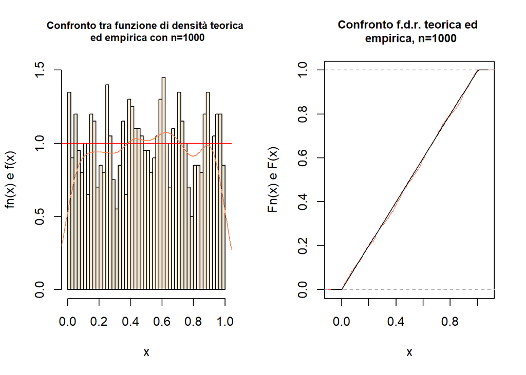

```r
par(mfrow =c(1,2))
# Funzione di densità
hist(det1, freq=FALSE, main="Confronto tra funzione di densità teorica \n ed empirica con n=1000", ylim=c(0,1.5), breaks=50,col="antiquewhite",cex.main=0.8, xlab="x",ylab="fn(x) e f(x)")
abline(1,0, col="RED")
points(density(det1), xlim=c(min(det1), max(det1)), col="coral", type="l")
# Funzione di ripartizione
plot(ecdf(det1), col="coral2", main= "Confronto f.d.r. teorica ed \n empirica, n=1000", ylab="Fn(x) e F(x)", cex.main=0.9)
curve(punif, col="black", add=TRUE)
```

### Per n=10000 determinazioni simulate

```r
# Indici sintetici
n=10000
det2<-runif(n,0,1)
mean(det2)
```

```
## [1] 0.5008052
```

```r
var(det2)
```

```
## [1] 0.08308828
```

```r
# I valori teorici sono rispettivamente 0.5 e (1-0)/12=0,083333
```

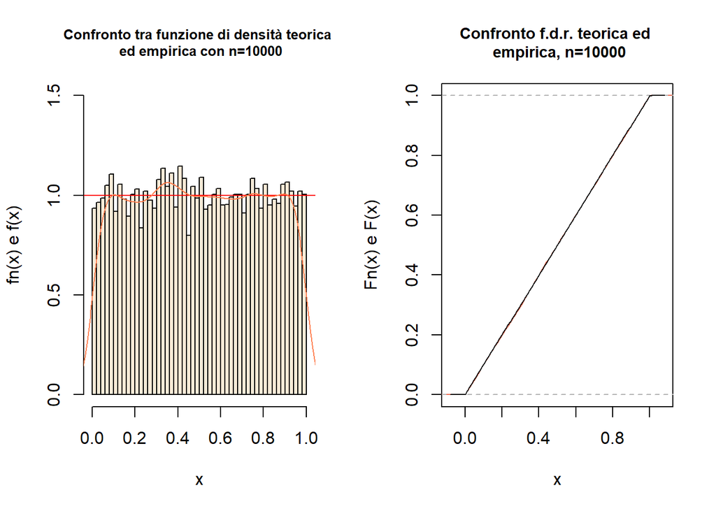

```r
par(mfrow =c(1,2))
# Funzione di densità
hist(det2, freq=FALSE, main="Confronto tra funzione di densità teorica \n ed empirica con n=10000", ylim=c(0,1.5), breaks=50,col="antiquewhite",cex.main=0.8, xlab="x",ylab="fn(x) e f(x)")
abline(1,0, col="RED")
points(density(det2), xlim=c(min(det2), max(det2)), col="coral", type="l")
# Funzione di ripartizione
plot(ecdf(det2), col="coral2", main= "Confronto f.d.r. teorica ed \n empirica, n=10000", ylab="Fn(x) e F(x)", cex.main=0.9)
curve(punif, col="black", add=TRUE)
```

### Confronto fra de1 e det2

```r
mean(det1)
```

```
## [1] 0.5037634
```

```r
mean(det2)
```

```
## [1] 0.5008052
```

```r
var(det1)
```

```
## [1] 0.08427377
```

```r
var(det2)
```

```
## [1] 0.08308828
```

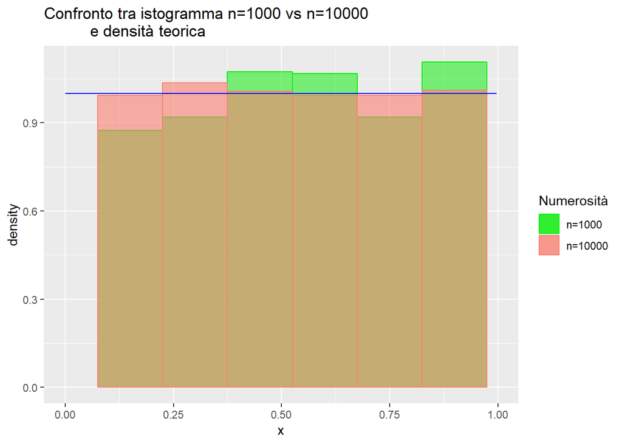

```r
# Funzioni di densità
data1 <- data.frame(det1)
data2 <- data.frame(det2)
ggplot(data.frame(x=c(-5,5)), aes(x)) +
  geom_histogram(aes(x=det1, y=..density.., fill="g", colour="g"), alpha=0.5, data=data1, binwidth = 0.15) +
  geom_histogram(aes(x=det2,y=..density.., fill="s", colour="s"), alpha=0.6, data=data2, binwidth = 0.15) +
  scale_colour_manual(name="Numerosità", values=c("g" = "green2", "s"="salmon"), labels=c("s"="n=10000", "g"="n=1000")) +
  scale_fill_manual(name="Numerosità", values=c("g" = "green2", "s"="salmon"),labels=c("s"="n=10000", "g"="n=1000")) +
    xlim(c(min(det1),max(det1))) +
  stat_function(fun=dunif, color="blue")+
ggtitle("Confronto tra istogramma n=1000 vs n=10000
          e densità teorica")
```

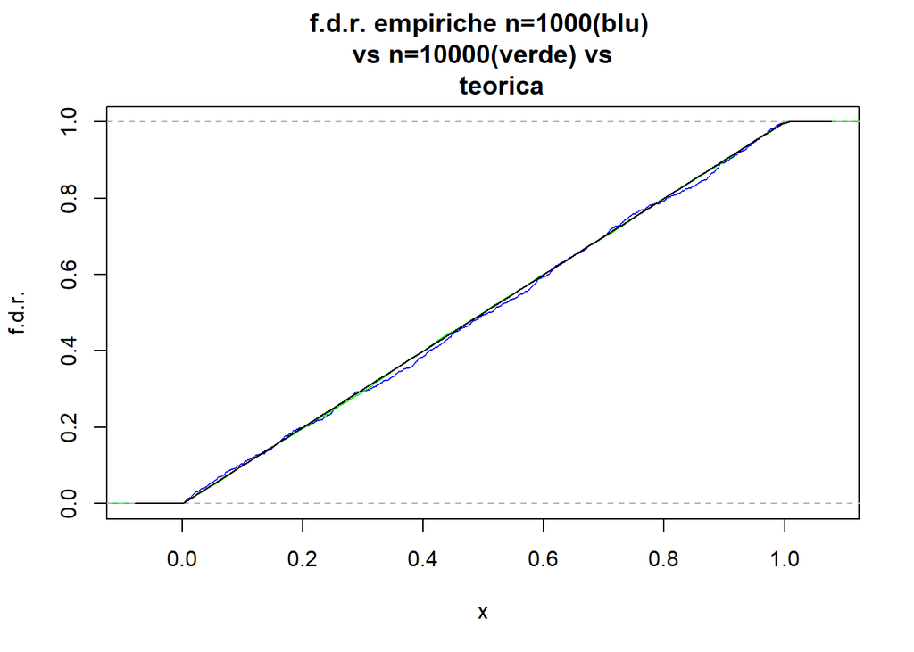

```r
# Funzioni di ripartizione
plot(ecdf(det1), col="blue",
main="f.d.r. empiriche n=1000(blu) \n vs n=10000(verde) vs
     teorica", xlab="x", ylab="f.d.r.")
plot(ecdf(det2), col="green2", add=T)
curve(punif, col="black", add=TRUE)
```

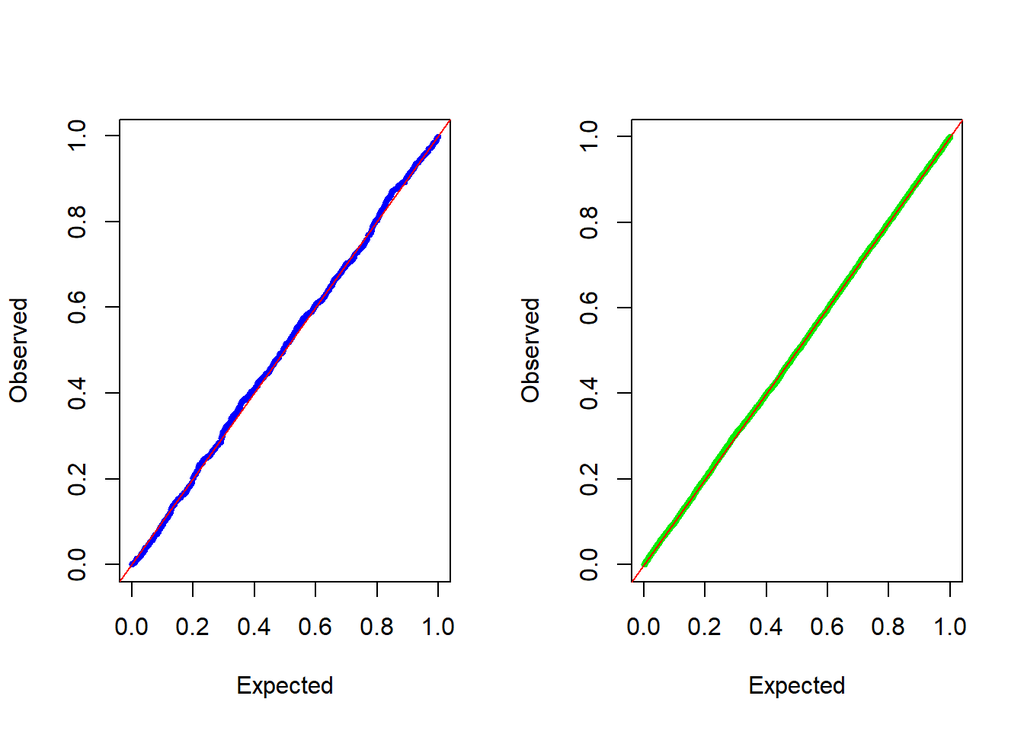

```r
# QQ-plot
par(mfrow =c(1,2))
qqunif(det1, type="unif",col="blue",cex = 0.5, logscale=FALSE, alpha=0.5)
qqunif(det2, type="unif",cex = 0.5,col="green2",logscale=FALSE)
```